# DA5030 - Practice Questions 1

Saheed Bachu

**1. Install RStudio**

**2. Download dataset** https://da5030.weebly.com/uploads/8/6/5/9/8659576/customertxndata.csv

```r
txn_dat <- read.csv("https://da5030.weebly.com/uploads/8/6/5/9/8659576/customertxndata.csv",
                    stringsAsFactors = FALSE, check.names = FALSE,
                    col.names = c("visits", "transactions", "os", "gender", "revenue")) ## data does not have col names
head(txn_dat)
```

|  | visits | transactions | os | gender | revenue |
| --- | --- | --- | --- | --- | --- |
| 1 | 20 | 1 | iOS | NA | 576.8668 |
| 2 | 22 | 1 | iOS | Female | 850.0000 |
| 3 | 24 | 2 | iOS | Female | 1050.0000 |
| 4 | 1 | 0 | Android | Male | 0.0000 |
| 5 | 13 | 1 | Android | Male | 460.0000 |
| 6 | 23 | 2 | iOS | Male | 1850.0000 |

**3. Calculate the following summative statistics: total transaction amount (revenue), mean number of visits, median revenue, standard deviation of revenue, most common gender. Exclude any cases where there is a missing value.**

```r
sprintf("total revenue = %f", sum(txn_dat$revenue, na.rm = T))
```

```
[1] "total revenue = 10372523.723881"
```

```r
sprintf("mean visits = %f", mean(txn_dat$visits))
```

```
[1] "mean visits = 12.486732"
```

```r
sprintf("median revenue = %f", median(txn_dat$revenue, na.rm = T))
```

```
[1] "median revenue = 344.651614"
```

```r
sprintf("standard deviation revenue = %f", sd(txn_dat$revenue, na.rm = T))
```

```
[1] "standard deviation revenue = 425.987075"
```

```r
## calculate mode
gender_noNA   <- txn_dat$gender[!is.na(txn_dat$gender)] ## remove NAs
genders       <- unique(txn_dat$gender[!is.na(txn_dat$gender)]) ## get unique genders
gender_counts <- sapply(genders, function(x) { length(grep(x, gender_noNA)) }) ## count unique genders
mode          <- names(which(gender_counts == max(gender_counts))) ## determine most common gender
sprintf("most common gender = %s", mode)
```

```
[1] "most common gender = Male"
```

**4. Create a bar/column chart of gender (x-axis) versus revenue (y-axis). Omit missing values, i.e., where gender is NA or missing.**

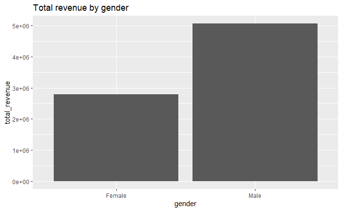

```r
library(magrittr)
library(dplyr)
library(ggplot2)

gender_revenue <- txn_dat %>% filter(!is.na(gender)) %>%
    group_by(gender) %>% summarise(total_revenue = sum(revenue))

ggplot(gender_revenue,
       aes(x = gender, y = total_revenue)) + geom_col() +
  labs(title = "Total revenue by gender")
```

**5. What is the Pearson Moment of Correlation between number of visits and revenue? Comment on the correlation.**

```r
cor(txn_dat$visits, txn_dat$revenue)
```

```
[1] 0.7388375
```

Revenue is highly correlated with the number of visits

**6. Which columns have missing data? How did you recognize them? How would you impute missing values?**

Missing data can be identified using `Hmisc::describe()`

```r
Hmisc::describe(txn_dat)
```

```
txn_dat

 5  Variables      22799  Observations
------------------------------------------------------------------------------------------------------------------------
visits
       n  missing distinct     Info     Mean      Gmd      .05      .10      .25      .50      .75      .90      .95
   22799        0       26    0.999    12.49    8.592        1        2        6       12       19       23       24

lowest :  0  1  2  3  4, highest: 21 22 23 24 25
------------------------------------------------------------------------------------------------------------------------
transactions
       n  missing distinct     Info     Mean      Gmd
   20999     1800        3    0.726    0.993   0.5899

Value          0     1     2
Frequency   3849 13447  3703
Proportion 0.183 0.640 0.176
------------------------------------------------------------------------------------------------------------------------
os
       n  missing distinct
   22799        0        2

Value      Android     iOS
Frequency    16027    6772
Proportion   0.703   0.297
------------------------------------------------------------------------------------------------------------------------
gender
       n  missing distinct
   17399     5400        2

Value      Female   Male
Frequency    2670  14729
Proportion  0.153  0.847
------------------------------------------------------------------------------------------------------------------------
revenue
       n  missing distinct     Info     Mean      Gmd      .05      .10      .25      .50      .75      .90      .95
   22799        0      115    0.993      455    438.2      0.0      0.0    170.0    344.7    576.9   1200.0   1350.0

lowest :    0.0000  100.0000  110.0000  120.0000  121.7745, highest: 1800.0000 1850.0000 1900.0000 1950.0000 2000.0000
------------------------------------------------------------------------------------------------------------------------
```

NAs are found in the `transactions` and `gender` columns. Values can be imputed using the mean or median value for `transactions`. Alternatively, the mode can be used for imputing categorical values like gender:

```r
txn_dat %>% mutate(transactions = replace_na(transactions, round(mean(transactions, na.rm = T))),
                   gender = replace_na(gender, mode)) %>% Hmisc::describe()
```

```
.

 5  Variables      22799  Observations
------------------------------------------------------------------------------------------------------------------------
visits
       n  missing distinct     Info     Mean      Gmd      .05      .10      .25      .50      .75      .90      .95
   22799        0       26    0.999    12.49    8.592        1        2        6       12       19       23       24

lowest :  0  1  2  3  4, highest: 21 22 23 24 25
------------------------------------------------------------------------------------------------------------------------
transactions
       n  missing distinct     Info     Mean      Gmd
   22799        0        3    0.692   0.9936   0.5527

Value          0     1     2
Frequency   3849 15247  3703
Proportion 0.169 0.669 0.162
------------------------------------------------------------------------------------------------------------------------
os
       n  missing distinct
   22799        0        2

Value      Android     iOS
Frequency    16027    6772
Proportion   0.703   0.297
------------------------------------------------------------------------------------------------------------------------
gender
       n  missing distinct
   22799        0        2

Value      Female   Male
Frequency    2670  20129
Proportion  0.117  0.883
------------------------------------------------------------------------------------------------------------------------
revenue
       n  missing distinct     Info     Mean      Gmd      .05      .10      .25      .50      .75      .90      .95
   22799        0      115    0.993      455    438.2      0.0      0.0    170.0    344.7    576.9   1200.0   1350.0

lowest :    0.0000  100.0000  110.0000  120.0000  121.7745, highest: 1800.0000 1850.0000 1900.0000 1950.0000 2000.0000
------------------------------------------------------------------------------------------------------------------------
```

**7. Impute missing transaction and gender values. Use the mean for transaction (rounded to the nearest whole number) and the mode for gender.**

```r
txn_dat <- txn_dat %>% mutate(transactions = replace_na(transactions, round(mean(transactions, na.rm = T))),
                   gender = replace_na(gender, mode))
```

**8. Split the data set into two equally sized data sets where one can be used for training a model and the other for validation. Take every odd numbered case and add them to the training data set and every even numbered case and add them to the validation data set, i.e., row 1, 3, 5, 7, etc. are training data while rows 2, 4, 6, etc. are validation data.**

```r
txn_train <- txn_dat[seq(1, nrow(txn_dat), 2), ]
txn_val <- txn_dat[seq(2, nrow(txn_dat), 2), ]
```

**9. Calculate the mean revenue for the training and the validation data sets and compare them. Comment on the difference.**

```r
sprintf("training data mean revenue: %f", mean(txn_train$revenue))
```

```
[1] "training data mean revenue: 460.260014"
```

```r
sprintf("validation data mean revenue: %f", mean(txn_val$revenue))
```

```
[1] "validation data mean revenue: 449.649931"
```

```r
sprintf("there is a %f%% difference between the revenue means of the validation and training datasets.",
        (mean(txn_train$revenue) -  mean(txn_val$revenue)) * 100 / mean(txn_train$revenue))
```

```
[1] "there is a 2.305237% difference between the revenue means of the validation and training datasets."
```

**10. For many data mining and machine learning tasks, there are packages in R. Use the sample() function to split the data set, so that 60% is used for training and 20% is used for testing, and another 20% is used for validation. To ensure that your code is reproducible and that everyone gets the same result, use the number 77654 as your seed for the random number generator.**

```r
set.seed(77654)
sample_train <- sample(nrow(txn_dat), floor(.6 * nrow(txn_dat)), replace = F)
txn_train <- txn_dat[sample_train, ]
test_val <- txn_dat[-sample_train, ]

sample_test_val <- sample(nrow(test_val), floor(.5 * nrow(test_val)), replace = F)
txn_test <- test_val[sample_test_val, ]
txn_val <- test_val[-sample_test_val, ]
```